# SMML Class 14 Lab

John Kubale

12/5/2022

```r
data(teengamb,package="faraway")
dim(teengamb)
```

```
## [1] 47  5
```

```r
summary(teengamb)
```

```
##       sex             status          income           verbal
##  Min.   :0.0000   Min.   :18.00   Min.   : 0.600   Min.   : 1.00
##  1st Qu.:0.0000   1st Qu.:28.00   1st Qu.: 2.000   1st Qu.: 6.00
##  Median :0.0000   Median :43.00   Median : 3.250   Median : 7.00
##  Mean   :0.4043   Mean   :45.23   Mean   : 4.642   Mean   : 6.66
##  3rd Qu.:1.0000   3rd Qu.:61.50   3rd Qu.: 6.210   3rd Qu.: 8.00
##  Max.   :1.0000   Max.   :75.00   Max.   :15.000   Max.   :10.00
##      gamble
##  Min.   :  0.0
##  1st Qu.:  1.1
##  Median :  6.0
##  Mean   : 19.3
##  3rd Qu.: 19.4
##  Max.   :156.0
```

## 1. Try the code given in each chunk and make observations for each question.

### 1.A. What are , and in the chunk below? Compare the results with a student next to you.

```r
gamble<-teengamb$gamble
gamble
```

```
##  [1]   0.00   0.00   0.00   7.30  19.60   0.10   1.45   6.60   1.70   0.10
## [11]   0.10   5.40   1.20   3.60   2.40   3.40   0.10   8.40  12.00   0.00
## [21]   1.00   1.20   0.10 156.00  38.50   2.10  14.50   3.00   0.60   9.60
## [31]  88.00  53.20  90.00   3.00  14.10  70.00  38.50  57.20   6.00  25.00
## [41]   6.90  69.70  13.30   0.60  38.00  14.40  19.20
```

```r
samp_gamble<-sample(gamble,10,replace=T)
samp_gamble
```

```
##  [1] 19.2  3.0 38.5  0.6  3.0 88.0 14.4  3.4  0.1 13.3
```

```r
mean_gamble<-mean(samp_gamble)
mean_gamble
```

```
## [1] 18.35
```

### 1.B. What does mean_gamble look like before and after ? What role does play?

```r
mean_gamble<-rep(0,5)

for(i in 1:5){
  samp_gamble<-sample(gamble,5,replace=T)
  mean_gamble[i]<-mean(samp_gamble)
  }
```

### 1.C. What is the value you obtain under ? Check your results of mean_gamble after and with the student next to you.

```r
mean_gamble
```

```
## [1]  4.14  7.56 17.79  4.98 84.08
```

```r
mean(mean_gamble)
```

```
## [1] 23.71
```

### 1.D. Check your results of after and against the results of the student next to you.

```r
set.seed(22)

for(i in 1:5){
  samp_gamble<-sample(gamble,47,replace=T)
  mean_gamble[i]<-mean(samp_gamble)
  }

mean_gamble
```

```
## [1] 25.41277 25.41277 17.80851 15.52447 20.79894
```

```r
mean(mean_gamble)
```

```
## [1] 20.99149
```

### 1.E. What did we just do? How could this exercise be helpful?

## 2. Bootstrap

### 2.A. We will use data from . Our interest is to construct a 95% confidence interval of $\mu_{glyhb}$ through the following steps:

1. Explore the data.
2. Draw 1000 bootstrap samples from (after properly dealing with any missing) using .
3. For each bootstrap sample, compute $\hat{\mu}_{glyhb,r}$, where $r$ indicates a bootstrap sample ($r=1,\cdots,1000$).
4. Observe the mean and standard deviation of $\hat{\mu}_{glyhb,r}$.
5. Using the results from d, construct a 95% confidence interval.
6. On the ranking of $\hat{\mu}_{glyhb,r}$, find the 25th and 975th value of $\hat{\mu}_{glyhb,r}$.
7. Compare $\hat{\mu}_{glyhb}$, $SE(\hat{\mu}_{glyhb})$ and the 95% CI of $\mu_{glyhb}$ from parametric estimation with the equivalents from bootstrapping. Consider CI’s from bootstrapping both in e and f. What do you observe?

### Step a. Explore the data

```r
data(diabetes,package = "faraway")
summary(diabetes)
```

```
##        id             chol          stab.glu          hdl
##  Min.   : 1000   Min.   : 78.0   Min.   : 48.0   Min.   : 12.00
##  1st Qu.: 4792   1st Qu.:179.0   1st Qu.: 81.0   1st Qu.: 38.00
##  Median :15766   Median :204.0   Median : 89.0   Median : 46.00
##  Mean   :15978   Mean   :207.8   Mean   :106.7   Mean   : 50.45
##  3rd Qu.:20336   3rd Qu.:230.0   3rd Qu.:106.0   3rd Qu.: 59.00
##  Max.   :41756   Max.   :443.0   Max.   :385.0   Max.   :120.00
##                  NA's   :1                       NA's   :1
##      ratio            glyhb             location        age           gender
##  Min.   : 1.500   Min.   : 2.68   Buckingham:200   Min.   :19.00   male  :169
##  1st Qu.: 3.200   1st Qu.: 4.38   Louisa    :203   1st Qu.:34.00   female:234
##  Median : 4.200   Median : 4.84                    Median :45.00
##  Mean   : 4.522   Mean   : 5.59                    Mean   :46.85
##  3rd Qu.: 5.400   3rd Qu.: 5.60                    3rd Qu.:60.00
##  Max.   :19.300   Max.   :16.11                    Max.   :92.00
##  NA's   :1        NA's   :13
##      height          weight         frame         bp.1s           bp.1d
##  Min.   :52.00   Min.   : 99.0   small :104   Min.   : 90.0   Min.   : 48.00
##  1st Qu.:63.00   1st Qu.:151.0   medium:184   1st Qu.:121.2   1st Qu.: 75.00
##  Median :66.00   Median :172.5   large :103   Median :136.0   Median : 82.00
##  Mean   :66.02   Mean   :177.6   NA's  : 12   Mean   :136.9   Mean   : 83.32
##  3rd Qu.:69.00   3rd Qu.:200.0                3rd Qu.:146.8   3rd Qu.: 90.00
##  Max.   :76.00   Max.   :325.0                Max.   :250.0   Max.   :124.00
##  NA's   :5       NA's   :1                    NA's   :5       NA's   :5
##      bp.2s           bp.2d            waist           hip
##  Min.   :110.0   Min.   : 60.00   Min.   :26.0   Min.   :30.00
##  1st Qu.:138.0   1st Qu.: 84.00   1st Qu.:33.0   1st Qu.:39.00
##  Median :149.0   Median : 92.00   Median :37.0   Median :42.00
##  Mean   :152.4   Mean   : 92.52   Mean   :37.9   Mean   :43.04
##  3rd Qu.:161.0   3rd Qu.:100.00   3rd Qu.:41.0   3rd Qu.:46.00
##  Max.   :238.0   Max.   :124.00   Max.   :56.0   Max.   :64.00
##  NA's   :262     NA's   :262      NA's   :2      NA's   :2
##     time.ppn
##  Min.   :   5.0
##  1st Qu.:  90.0
##  Median : 240.0
##  Mean   : 341.2
##  3rd Qu.: 517.5
##  Max.   :1560.0
##  NA's   :3
```

```r
names(diabetes)
```

```
##  [1] "id"       "chol"     "stab.glu" "hdl"      "ratio"    "glyhb"
##  [7] "location" "age"      "gender"   "height"   "weight"   "frame"
## [13] "bp.1s"    "bp.1d"    "bp.2s"    "bp.2d"    "waist"    "hip"
## [19] "time.ppn"
```

```r
glyhb<-diabetes%>%
  select(glyhb)%>%
  na.omit()

dim(diabetes)
```

```
## [1] 403  19
```

```r
dim(glyhb)
```

```
## [1] 390   1
```

### Step b. Draw 1000 bootstrap samples from (after properly dealing with any missing) using .

### Step c. For each bootstrap sample, compute $\hat{\mu}_{glyhb,r}$, where $r$ indicates a bootstrap sample ($r=1,\cdots,1000$).

```r
n_boot<-1000
set.seed(9)
n_glyhb<-dim(glyhb)[1]

mean_glyhb<-rep(0,n_boot)

for(i in 1:n_boot){
  samp_glyhb<-glyhb%>%
    sample_n(n_glyhb,replace=T)
  mean_glyhb[i]<-mean(samp_glyhb$glyhb)
  }

head(mean_glyhb)
```

```
## [1] 5.632051 5.422128 5.597359 5.644051 5.698410 5.567692
```

### Step d. Observe the mean and standard deviation of $\hat{\mu}_{glyhb,r}$.

```r
mean(mean_glyhb)
```

```
## [1] 5.588704
```

```r
sd(mean_glyhb)
```

```
## [1] 0.1143233
```

### Step e. Using the results from d, construct a 95% confidence interval.

```r
t.score<-qt(p=.05/2, df=dim(glyhb)[1]-1, lower.tail=F)

Lci<-mean(mean_glyhb)-t.score*sd(mean_glyhb)
Uci<-mean(mean_glyhb)+t.score*sd(mean_glyhb)

print(c(Lci,Uci))
```

```
## [1] 5.363936 5.813473
```

### Step f. On the ranking of $\hat{\mu}_{glyhb,r}$, find the 25th and 975th value of $\hat{\mu}_{glyhb,r}$.

```r
quantile(mean_glyhb,c(0.025,0.975))
```

```
##     2.5%    97.5%
## 5.372001 5.805876
```

### Step g. Compare $\hat{\mu}_{glyhb}$, $SE(\hat{\mu}_{glyhb})$ and the 95% CI of $\mu_{glyhb}$ from parametric estimation with the equivalents from bootstrapping. Consider CI’s from bootstrapping both in e and f. What do you observe?

```r
mean(glyhb$glyhb); mean(mean_glyhb)
```

```
## [1] 5.589769
```

```
## [1] 5.588704
```

```r
sd(glyhb$glyhb)/sqrt(dim(glyhb)[1]); sd(mean_glyhb)
```

```
## [1] 0.1135582
```

```
## [1] 0.1143233
```

```r
t.test(glyhb$glyhb)$"conf.int";
```

```
## [1] 5.366505 5.813034
## attr(,"conf.level")
## [1] 0.95
```

```r
print(c(Lci,Uci));
```

```
## [1] 5.363936 5.813473
```

```r
quantile(mean_glyhb,c(0.025,0.975))
```

```
##     2.5%    97.5%
## 5.372001 5.805876
```

### 2.B. Continue with data from . The interest is estimating a slope coefficient of a linear regression model ~ through the following steps.

1. Examine the model with respect to OLS assumptions. What does the conclusion tell you?
2. Focus on $\beta_{chol}$ from the model. Compute its bootstrap standard error as well as the 95% confidence interval. Use 1000 bootstrap samples.
3. Bootstrap confidence interval using R functions and .
4. Compare the estimate for $\beta_{chol}$ using OLS and bootstrapping (in b).
5. Compare the 95% confidence interval for $\beta_{chol}$ using OLS, bootstrapping (in b) and heteroscedacity consistent variance estimator.

### Step a. Examine the model with respect to OLS assumptions. What does the conclusion tell you?

```r
summary(diabetes)
```

```
##        id             chol          stab.glu          hdl
##  Min.   : 1000   Min.   : 78.0   Min.   : 48.0   Min.   : 12.00
##  1st Qu.: 4792   1st Qu.:179.0   1st Qu.: 81.0   1st Qu.: 38.00
##  Median :15766   Median :204.0   Median : 89.0   Median : 46.00
##  Mean   :15978   Mean   :207.8   Mean   :106.7   Mean   : 50.45
##  3rd Qu.:20336   3rd Qu.:230.0   3rd Qu.:106.0   3rd Qu.: 59.00
##  Max.   :41756   Max.   :443.0   Max.   :385.0   Max.   :120.00
##                  NA's   :1                       NA's   :1
##      ratio            glyhb             location        age           gender
##  Min.   : 1.500   Min.   : 2.68   Buckingham:200   Min.   :19.00   male  :169
##  1st Qu.: 3.200   1st Qu.: 4.38   Louisa    :203   1st Qu.:34.00   female:234
##  Median : 4.200   Median : 4.84                    Median :45.00
##  Mean   : 4.522   Mean   : 5.59                    Mean   :46.85
##  3rd Qu.: 5.400   3rd Qu.: 5.60                    3rd Qu.:60.00
##  Max.   :19.300   Max.   :16.11                    Max.   :92.00
##  NA's   :1        NA's   :13
##      height          weight         frame         bp.1s           bp.1d
##  Min.   :52.00   Min.   : 99.0   small :104   Min.   : 90.0   Min.   : 48.00
##  1st Qu.:63.00   1st Qu.:151.0   medium:184   1st Qu.:121.2   1st Qu.: 75.00
##  Median :66.00   Median :172.5   large :103   Median :136.0   Median : 82.00
##  Mean   :66.02   Mean   :177.6   NA's  : 12   Mean   :136.9   Mean   : 83.32
##  3rd Qu.:69.00   3rd Qu.:200.0                3rd Qu.:146.8   3rd Qu.: 90.00
##  Max.   :76.00   Max.   :325.0                Max.   :250.0   Max.   :124.00
##  NA's   :5       NA's   :1                    NA's   :5       NA's   :5
##      bp.2s           bp.2d            waist           hip
##  Min.   :110.0   Min.   : 60.00   Min.   :26.0   Min.   :30.00
##  1st Qu.:138.0   1st Qu.: 84.00   1st Qu.:33.0   1st Qu.:39.00
##  Median :149.0   Median : 92.00   Median :37.0   Median :42.00
##  Mean   :152.4   Mean   : 92.52   Mean   :37.9   Mean   :43.04
##  3rd Qu.:161.0   3rd Qu.:100.00   3rd Qu.:41.0   3rd Qu.:46.00
##  Max.   :238.0   Max.   :124.00   Max.   :56.0   Max.   :64.00
##  NA's   :262     NA's   :262      NA's   :2      NA's   :2
##     time.ppn
##  Min.   :   5.0
##  1st Qu.:  90.0
##  Median : 240.0
##  Mean   : 341.2
##  3rd Qu.: 517.5
##  Max.   :1560.0
##  NA's   :3
```

```r
diab<-diabetes%>%
  select(glyhb,chol)%>%
  na.omit() # drops missing observations

mod<-lm(glyhb~chol,diab)
summary(mod)
```

```
##
## Call:
## lm(formula = glyhb ~ chol, data = diab)
##
## Residuals:
##     Min      1Q  Median      3Q     Max
## -2.7911 -1.2187 -0.6495  0.1696  9.4164
##
## Coefficients:
##             Estimate Std. Error t value Pr(>|t|)
## (Intercept) 3.022246   0.524240   5.765 1.67e-08 ***
## chol        0.012403   0.002472   5.017 8.03e-07 ***
## ---
## Signif. codes:  0 '***' 0.001 '**' 0.01 '*' 0.05 '.' 0.1 ' ' 1
##
## Residual standard error: 2.178 on 387 degrees of freedom
## Multiple R-squared:  0.06106,    Adjusted R-squared:  0.05863
## F-statistic: 25.17 on 1 and 387 DF,  p-value: 8.032e-07
```

```r
coef(mod)
```

```
## (Intercept)        chol
##  3.02224607  0.01240328
```

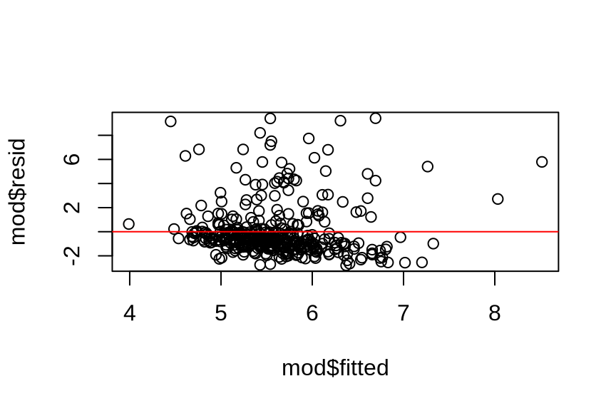

```r
plot(mod$fitted,mod$resid);abline(h=0,col="red")
```

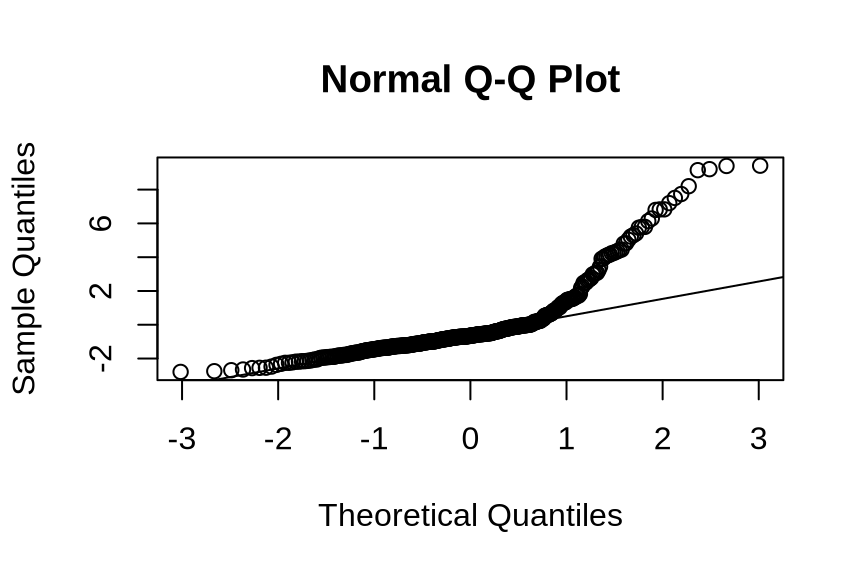

```r
qqnorm(mod$resid);qqline(mod$resid)
```

```r
# What do these plots suggest about our linear regression assumptions? Do they appear to be met?
```

### Step b. Focus on $\beta_{chol}$ from the model. Compute its bootstrap standard error as well as the 95% confidence interval. Use 1000 bootstrap samples.

```r
n_boot<-1000
set.seed(21)
n_diab<-dim(diab)[1] # get dimensions of first column of diab

beta_chol<-rep(0,n_boot) # create vector the length of n_boot to give something for for loop to store values in

# this code might take a second to run
for(i in 1:n_boot){
samp_diab<-diab%>%
  sample_n(n_diab,replace=T)
bmod<-lm(glyhb~chol,samp_diab)
beta_chol[i]<-coef(bmod)[2]
  }

mean(beta_chol)
```

```
## [1] 0.01238331
```

```r
sd(beta_chol)
```

```
## [1] 0.003435593
```

```r
t.score<-qt(p=.05/2, df=n_diab-1, lower.tail=F)

Lci<-mean(beta_chol)-t.score*sd(beta_chol)
Uci<-mean(beta_chol)+t.score*sd(beta_chol)

print(c(Lci,Uci))
```

```
## [1] 0.00562860 0.01913802
```

```r
quantile(beta_chol,c(0.025,0.975))
```

```
##       2.5%      97.5%
## 0.00532068 0.01888977
```

### Step c. Bootstrap confidence interval using R functions and .

```r
boot.fn<-function(dat,i){
  return(coef(lm(glyhb~chol,data=dat,subset=i))[2])
  }

set.seed(29)
boot.fn(diab,sample(n_diab,n_diab,replace=T))
```

```
##       chol
## 0.01754396
```

```r
boot.fn(diab,sample(n_diab,n_diab,replace=T)) #why is the result different between these two (hint: look at line 22 and what is used as the 2nd argument when calling boot.fn())?
```

```
##       chol
## 0.01412256
```

```r
# Try running the following lines of code. What do you see?
set.seed(29)
boot.fn(diab,sample(n_diab,n_diab,replace=T))
```

```
##       chol
## 0.01754396
```

```r
set.seed(29)
boot.fn(diab,sample(n_diab,n_diab,replace=T))
```

```
##       chol
## 0.01754396
```

```r
a<-boot(diab,boot.fn,1000) #boot() from boot package
a
```

```
##
## ORDINARY NONPARAMETRIC BOOTSTRAP
##
##
## Call:
## boot(data = diab, statistic = boot.fn, R = 1000)
##
##
## Bootstrap Statistics :
##       original        bias    std. error
## t1* 0.01240328 -9.285092e-05 0.003421621
```

```r
attributes(a)
```

```
## $names
##  [1] "t0"        "t"         "R"         "data"      "seed"      "statistic"
##  [7] "sim"       "call"      "stype"     "strata"    "weights"
##
## $class
## [1] "boot"
##
## $boot_type
## [1] "boot"
```

```r
head(a)
```

[output not shown]

[output cut: 1500 more lines]

```r
quantile(a$t[,1],c(0.025,0.975))
```

```
##        2.5%       97.5%
## 0.005604824 0.018818134
```

```r
attributes(boot.ci(a))
```

```
## $names
## [1] "R"       "t0"      "call"    "normal"  "basic"   "percent" "bca"
##
## $class
## [1] "bootci"
```

```r
boot.ci(a)
```

```
## BOOTSTRAP CONFIDENCE INTERVAL CALCULATIONS
## Based on 1000 bootstrap replicates
##
## CALL :
## boot.ci(boot.out = a)
##
## Intervals :
## Level      Normal              Basic
## 95%   ( 0.0058,  0.0192 )   ( 0.0060,  0.0193 )
##
## Level     Percentile            BCa
## 95%   ( 0.0055,  0.0188 )   ( 0.0059,  0.0192 )
## Calculations and Intervals on Original Scale
```

### Step d. Compare the estimate for $\beta_{chol}$ using OLS and bootstrapping (in b).

```r
coef(mod)[2]; mean(beta_chol)
```

```
##       chol
## 0.01240328
```

```
## [1] 0.01238331
```

### Step e. Compare the 95% confidence interval for $\beta_{chol}$ using OLS, bootstrapping (in b) and heteroscedacity consistent variance estimator.

```r
confint(mod)[2,];
```

```
##       2.5 %      97.5 %
## 0.007542135 0.017264421
```

```r
print(c(Lci,Uci));
```

```
## [1] 0.00562860 0.01913802
```

```r
quantile(beta_chol,c(0.025,0.975))
```

```
##       2.5%      97.5%
## 0.00532068 0.01888977
```

```r
HCse<-mod %>%
  vcovHC() %>% #from sandwich package
  diag() %>%
  sqrt() # taking the square root here changes it to standard error (from variance)

t.score<-qt(p=.05/2, df=n_diab-1, lower.tail=F)

LHCci<-coef(mod)[2]-t.score*HCse[2]
UHCci<-coef(mod)[2]+t.score*HCse[2]

print(c(LHCci,UHCci))
```

```
##        chol        chol
## 0.005570644 0.019235911
```

## 3. Cross-Validation

### 3.A. Continue with the linear regression of ~ of diabetes. Try its general additive model and explore whether polynomials would be helpful.

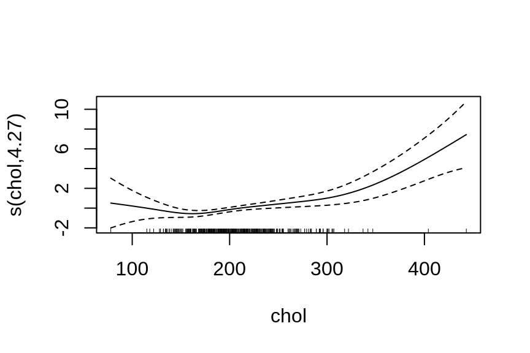

```r
modA<-gam(glyhb~s(chol),data=diab) #gam() from mgcv package
plot(modA)
```

```r
attributes(modA)
```

```
## $names
##  [1] "coefficients"      "residuals"         "fitted.values"
##  [4] "family"            "linear.predictors" "deviance"
##  [7] "null.deviance"     "iter"              "weights"
## [10] "prior.weights"     "df.null"           "y"
## [13] "converged"         "sig2"              "edf"
## [16] "edf1"              "hat"               "R"
## [19] "boundary"          "sp"                "nsdf"
## [22] "Ve"                "Vp"                "rV"
## [25] "mgcv.conv"         "gcv.ubre"          "aic"
## [28] "rank"              "gcv.ubre.dev"      "scale.estimated"
## [31] "method"            "smooth"            "formula"
## [34] "var.summary"       "cmX"               "model"
## [37] "control"           "terms"             "pred.formula"
## [40] "pterms"            "assign"            "offset"
## [43] "df.residual"       "min.edf"           "optimizer"
## [46] "call"
##
## $class
## [1] "gam" "glm" "lm"
```

```r
mod1<-glm(glyhb~chol,data=diab)
mod2<-glm(glyhb~poly(chol,2),data=diab)
mod3<-glm(glyhb~poly(chol,3),data=diab)
mod4<-glm(glyhb~poly(chol,4),data=diab)

mod1$df.residual;mod2$df.residual;mod3$df.residual;mod4$df.residual;modA$df.residual
```

```
## [1] 387
```

```
## [1] 386
```

```
## [1] 385
```

```
## [1] 384
```

```
## [1] 383.726
```

```r
mse<-function(obj){
  sum(obj$residuals^2)/obj$df.residual
  }

mse(mod1);mse(mod2);mse(mod3);mse(mod4);mse(modA)
```

```
## [1] 4.742389
```

```
## [1] 4.642598
```

```
## [1] 4.64889
```

```
## [1] 4.623265
```

```
## [1] 4.606616
```

### 3.B. Using the validation set approach:

### Try the validation set approach and observe the error rates. What does this mean?

```r
set.seed(31)

train_i<-sample(n_diab,round(n_diab/2,0))

train<-diab[train_i,]
val<-diab[-train_i,]

mod1.train<-glm(glyhb~chol,data=train)
mod2.train<-glm(glyhb~poly(chol,2),data=train)
mod3.train<-glm(glyhb~poly(chol,3),data=train)
mod4.train<-glm(glyhb~poly(chol,4),data=train)

# compare observed values in treatment set to predicted values using model fit on training data
mean((val$glyhb-predict(mod1.train,val))^2)
```

```
## [1] 5.797965
```

```r
mean((val$glyhb-predict(mod2.train,val))^2)
```

```
## [1] 5.59064
```

```r
mean((val$glyhb-predict(mod3.train,val))^2)
```

```
## [1] 7.828022
```

```r
mean((val$glyhb-predict(mod4.train,val))^2)
```

```
## [1] 5.845769
```

### 3.C. Use leave-one-out and cross-validate.

```r
mod1.cv.err<-cv.glm(diab,mod1)
attributes(mod1.cv.err)
```

```
## $names
## [1] "call"  "K"     "delta" "seed"
```

```r
mod1.cv.err$delta
```

```
## [1] 4.789920 4.789826
```

```r
mod2.cv.err<-cv.glm(diab,mod2)
mod3.cv.err<-cv.glm(diab,mod3)
mod4.cv.err<-cv.glm(diab,mod4)

mod1.cv.err$delta;mod2.cv.err$delta;mod3.cv.err$delta;mod4.cv.err$delta
```

```
## [1] 4.789920 4.789826
```

```
## [1] 4.700798 4.700670
```

```
## [1] 4.741317 4.741107
```

```
## [1] 4.801336 4.800957
```

### 3.D. Use $k$-fold cross-validation with $k=10$.

```r
set.seed(6)
mod1.cv.err.kfold<-cv.glm(diab,mod1,K=10)
mod2.cv.err.kfold<-cv.glm(diab,mod2,K=10)
mod3.cv.err.kfold<-cv.glm(diab,mod3,K=10)
mod4.cv.err.kfold<-cv.glm(diab,mod4,K=10)

mod1.cv.err.kfold$delta
```

```
## [1] 4.759094 4.756912
```

```r
mod2.cv.err.kfold$delta
```

```
## [1] 4.700760 4.695643
```

```r
mod3.cv.err.kfold$delta
```

```
## [1] 5.852809 5.738315
```

```r
mod4.cv.err.kfold$delta
```

```
## [1] 4.883699 4.864094
```

```r
rbind(mod1.cv.err.kfold$delta[1],
      mod2.cv.err.kfold$delta[1],
      mod3.cv.err.kfold$delta[1],
      mod4.cv.err.kfold$delta[1])
```

```
##          [,1]
## [1,] 4.759094
## [2,] 4.700760
## [3,] 5.852809
## [4,] 4.883699
```

### 3.E. Given the results so far, which of the models 1 through 4 would you recommend?